# Examination of Postdoc Funding Opportunities at the University of Michigan

Alec Steep

20191015

## Explanation of Data

Annual salary data (PDF format) was obtained from UM’s hr website: https://hr.umich.edu/working-u-m/management-administration/hr-reports-data-services/hr-data-requests-standard-reports. The data was extracted from pdf format and cleaned for analysis within R.

[Github Repo](https://github.com/steepale/umich_salary)

Potential postdoc funding opportunities was generously provided by Aaron Reifler

## Setup the Environment

```r
################################################################################
##### Resources and Dependencies ###############################################
################################################################################

# Set the working directory
setwd('/Users/Alec/Documents/umich_salary')

# Load the dependencies
#source("https://bioconductor.org/biocLite.R")
#BiocManager::install("R.utils")
#install.packages("ggpubr")

# Load dependencies
pacs...man <- c("dplyr","tibble","magrittr","stringr", "data.table","readr","R.utils","ggplot2","ggpubr")
lapply(pacs...man, FUN = function(X) {
        do.call("library", list(X))
})
```

[output not shown]

```r
############################################################
##### Functions ############################################
############################################################

# Make the 'not in' operator
'%!in%' <- function(x,y) {
        !('%in%'(x,y))
}

# Capture the Date
date <- format.Date( Sys.Date(), '%Y%m%d' )
auth <- "steep"

################################################################################
```

## Load & Clean Data

##### Data Files to Load:

- UM Salary Information
- Postdoc Funding Opportunities

```r
################################################################################
#####     Load & Clean Data      ###############################################
################################################################################

# Load the postdoc funding information
tg <- read.table(file = '/Users/Alec/Documents/umich_salary/data/2019_training_grants.txt', header = TRUE, sep = '\t')
tg <- as_tibble(tg)

# Load in the salary data for all of UM (sorry y'all)
df <- read.table(file = "/Users/Alec/Documents/umich_salary/data/UMsalary.txt", header = TRUE, sep = '\t')
df <- as_tibble(df)

# Remove commas from income
df$APPT_ANNUAL_FTR <- str_replace(df$APPT_ANNUAL_FTR, ',', '') %>% as.numeric()
df <- df[!is.na(df$APPT_ANNUAL_FTR),]
```

## Add Features

##### Added Features:

- Annual Income
- Employee Identifiers

```r
################################################################################
#####     Add Features      ####################################################
################################################################################

# Calculate annual income
df$APPT_ANNUAL_INCOME <- df$APPT_ANNUAL_FTR / df$APPT_FTR_BASIS * 12

# How to assign unique identifiers? -- not neccessarily 100% accurate but good enough (Pareto distribution & efficiency)
# https://stackoverflow.com/questions/10118856/how-to-assign-a-unique-identifier-to-multiple-data-frame-entries
df$ID <- as.factor(as.numeric(as.factor(with(df, paste(CAMPUS, NAME, TITLE, sep="_")))))
#names(df)
# Sanity check
#rev(sort(table(df$ID)))

# Annotate employee year (only if not working in 2015 -- interested in 1st year postdocs)

# Create seperate data frame
# Check distinct value frequency based on column
#df %>% dplyr::select(NAME) %>% distinct() %>% dim()
#df %>% dplyr::select(ID) %>% distinct() %>% dim()
#df %>% distinct() %>% dim()

df_id <- as.data.frame(table(df$ID))
names(df_id) = c("ID", "YRS_POST_2015")
#str(df_id)
# perform left join
df <- left_join(df, df_id, by = "ID")

# Approximetely how many RESEARCH_FELLOWS? AKA mostly postdocs: 2,749 (maybe 2,700 postdocs)
#df %>% filter(TITLE == 'RESEARCH_FELLOW') %>% distinct(ID) %>% dim()
```

## Visualize the Data

- Dimensions
- Structure
- First Rows

```r
################################################################################
#####     Visualize Data      ##################################################
################################################################################
```

#### UM Salary Information:

```r
dim(df)
```

```
## [1] 183383     12
```

```r
str(df)
```

```
## Classes 'tbl_df', 'tbl' and 'data.frame':    183383 obs. of  12 variables:
##  $ CAMPUS            : Factor w/ 3 levels "UM_ANN-ARBOR",..: 1 1 1 1 1 1 1 1 1 1 ...
##  $ NAME              : Factor w/ 62445 levels "A-Rosales,Jessica",..: 4 6 7 9 10 8 12 13 13 14 ...
##  $ TITLE             : Factor w/ 2312 levels "A/C_&_REFRIGERATION_MECHANIC",..: 563 254 217 572 1745 1833 1745 1338 1751 1025 ...
##  $ DEPT              : Factor w/ 2981 levels "7B_Nursing","8CAP",..: 1732 1348 1439 608 1880 2519 1109 1601 1601 2179 ...
##  $ APPT_ANNUAL_FTR   : num  162432 62200 127150 54700 199091 ...
##  $ APPT_FTR_BASIS    : int  12 12 9 12 9 12 12 12 12 12 ...
##  $ APPT_FRACTION     : num  0.9 1 1 1 1 0.9 1 0.5 0.5 0.05 ...
##  $ PAID              : Factor w/ 40538 levels "0","0.00","1,000.00",..: 2 14509 5510 2 10103 2 16975 2 16475 2 ...
##  $ YEAR              : int  2015 2015 2015 2015 2015 2015 2015 2015 2015 2015 ...
##  $ APPT_ANNUAL_INCOME: num  162432 62200 169533 54700 265455 ...
##  $ ID                : Factor w/ 85003 levels "1","2","3","4",..: 5 7 8 10 11 9 13 14 16 17 ...
##  $ YRS_POST_2015     : int  1 1 3 2 4 2 4 1 2 4 ...
```

```r
head(df)
```

```
## # A tibble: 6 x 12
##   CAMPUS NAME  TITLE DEPT  APPT_ANNUAL_FTR APPT_FTR_BASIS APPT_FRACTION
##   <fct>  <fct> <fct> <fct>           <dbl>          <int>         <dbl>
## 1 UM_AN… Aage… CLIN… Phys…         162432.             12           0.9
## 2 UM_AN… Aarn… ASST… LSA_…          62200              12           1
## 3 UM_AN… Aarn… ASSO… LSA_…         127150               9           1
## 4 UM_AN… Aaro… Clin… Epid…          54700              12           1
## 5 UM_AN… Aaro… PROF… Scho…         199091               9           1
## 6 UM_AN… Aaro… REGI… UMH_…          64646.             12           0.9
## # … with 5 more variables: PAID <fct>, YEAR <int>,
## #   APPT_ANNUAL_INCOME <dbl>, ID <fct>, YRS_POST_2015 <int>
```

#### Postdoc Funding Opportunities:

```r
dim(tg)
```

```
## [1] 43  8
```

```r
str(tg)
```

```
## Classes 'tbl_df', 'tbl' and 'data.frame':    43 obs. of  8 variables:
##  $ GRANT_TITLE     : Factor w/ 42 levels "Advanced_Research_Training_in_Otolaryngology",..: 37 39 3 35 27 8 38 36 9 4 ...
##  $ PROFESSOR       : Factor w/ 43 levels "Auchus,Richard",..: 8 3 15 41 42 16 43 30 13 27 ...
##  $ DEPARTMENT      : Factor w/ 36 levels "Anesthesiology",..: 1 2 3 4 5 6 7 8 9 10 ...
##  $ EMAIL           : Factor w/ 43 levels "aslok@umich.edu",..: 5 2 11 9 37 31 43 17 30 36 ...
##  $ OPEN_POSITIONS  : int  2 1 3 2 3 3 3 1 2 3 ...
##  $ POSTDOC_PREVIEW : int  0 0 1 0 1 0 0 1 0 0 ...
##  $ RESEARCH_SIMILAR: int  1 2 2 1 1 1 1 1 1 1 ...
##  $ YEAR            : int  2019 2019 2019 2019 2019 2019 2019 2019 2019 2019 ...
```

```r
head(tg)
```

```
## # A tibble: 6 x 8
##   GRANT_TITLE PROFESSOR DEPARTMENT EMAIL OPEN_POSITIONS POSTDOC_PREVIEW
##   <fct>       <fct>     <fct>      <fct>          <int>           <int>
## 1 University… Clauw,Da… Anesthesi… dcla…              2               0
## 2 University… Boehnke,… Biostatis… boeh…              1               0
## 3 Cancer_Bio… Lawlor,E… Cancer_Ce… elaw…              3               1
## 4 Training_P… Wellik,D… Center_fo… dwel…              2               0
## 5 Training_G… Wong,Sun… Dermatolo… sunn…              3               1
## 6 Environmen… Loch‐Car… Environme… rlc@…              3               0
## # … with 2 more variables: RESEARCH_SIMILAR <int>, YEAR <int>
```

## Determine the Frequency of First Year Postdocs

```r
################################################################################
############ Determine Income for 1st Year Postdocs ############################
################################################################################

# Create a dataframe of first year postdocs (from 2016 - 2018)
df_pd <- filter(df, TITLE == 'RESEARCH_FELLOW' & YRS_POST_2015 == 1 & YEAR != 2015)

# Refactor some columns
df_pd$DEPT <- as.character(df_pd$DEPT)
df_pd$DEPT <- as.factor(df_pd$DEPT)

# Count the number of first year postdocs over a 3 year period: 915
# df_pd %>% dplyr::select(ID) %>% distinct() %>% dim()
# dim(df_pd)
# -- No redundant names
```

#### The Frequency of First Year Post Docs in the Past 3 Years

```r
# Postdoc Admittance frequency per year
# names(df_pd)
table(df_pd$YEAR)
```

```
##
## 2016 2017 2018
##  214  210  491
```

```r
# 2016 2017 2018
# 214  210  491

# Divide by 3 and consider average (305) and predicted value (human prediction 200-600)
```

It’s difficult to predict the number of postdocs this year (let alone the number looking for funding). I’ll take a conservative approach and assume UM will admit 200-600 postdocs and use 400 in the model. A more realistic model will come after collecting data from funders.

## Internal Training Grants Stats

```r
################################################################################
####### Stas on Number of Internal Training Grants #############################
################################################################################

# Stats: 139 opportunities
# Probability of winning award if everyone applied to one award: 0.3475

# Determine the number of open positions
fund_opps <- sum(tg$OPEN_POSITIONS)
# Predicted number of 1st year postdocs in 2019 (human estimate)
fypd <- 400

# Prob win and loss
PW <- fund_opps/fypd
PL <- 1-PW
```

Number of open positions:

```r
fund_opps
```

```
## [1] 139
```

Number of FYPD:

```r
fypd
```

```
## [1] 400
```

Probability of winning:

```r
PW
```

```
## [1] 0.3475
```

Don’t say it:

```r
!print(PL)
```

```
## [1] 0.6525
```

```
## [1] FALSE
```

In reality, the probability is dependant on the number of applicants and where motivation to fund applicant lies for funders. Next model will be more sophisticated to capture predicted variance for opportunities applied to.

## Model

#### How many positions would you need to apply to to ensure at least one fellowship with a 95% probability of success?

```r
################################################################################
####### Simulation #############################################################
################################################################################

# Number of fellowships to apply to to have high liklihood of winning >=95%

# Not true: NW <- ceiling(0.95/PW)

# Set the seed
set.seed(123)
# Trial numbers
M = 10000
# The number of amplications
AN = 10

x <- as.numeric()
y <- as.numeric()
# Run the sim
for (apps in 1:AN) {
        # Empty trials
        trials = c()
        # Perform an simulation in which a postdoc applies to n positions 100,000 times
        for (i in 1:M) {
                # Run the trial
                results <- sample(c('W','L'),apps,replace=TRUE,prob = c(PW,PL))
                if ('W' %in% results) {
                        WL <- TRUE
                }else{
                        WL <- FALSE
                }
                trials = c(trials, WL)
        }

        # Use table to visualize experiment
        NT <- as.numeric(table(trials)[2])
        NF <- as.numeric(table(trials)[1])
        N_TF <- NT + NF
        # Percentage of times the event has atleast 1 win
        PC <- NT/N_TF
        # Show results
        print(paste0('Number of applications: ',apps))
        print(paste0('Probability of getting at least one win: ',PC))
        x <- c(x,apps)
        y <- c(y, PC)
}
```

```
## [1] "Number of applications: 1"
## [1] "Probability of getting at least one win: 0.3427"
## [1] "Number of applications: 2"
## [1] "Probability of getting at least one win: 0.5732"
## [1] "Number of applications: 3"
## [1] "Probability of getting at least one win: 0.7152"
## [1] "Number of applications: 4"
## [1] "Probability of getting at least one win: 0.8248"
## [1] "Number of applications: 5"
## [1] "Probability of getting at least one win: 0.8871"
## [1] "Number of applications: 6"
## [1] "Probability of getting at least one win: 0.9203"
## [1] "Number of applications: 7"
## [1] "Probability of getting at least one win: 0.9484"
## [1] "Number of applications: 8"
## [1] "Probability of getting at least one win: 0.9668"
## [1] "Number of applications: 9"
## [1] "Probability of getting at least one win: 0.978"
## [1] "Number of applications: 10"
## [1] "Probability of getting at least one win: 0.9853"
```

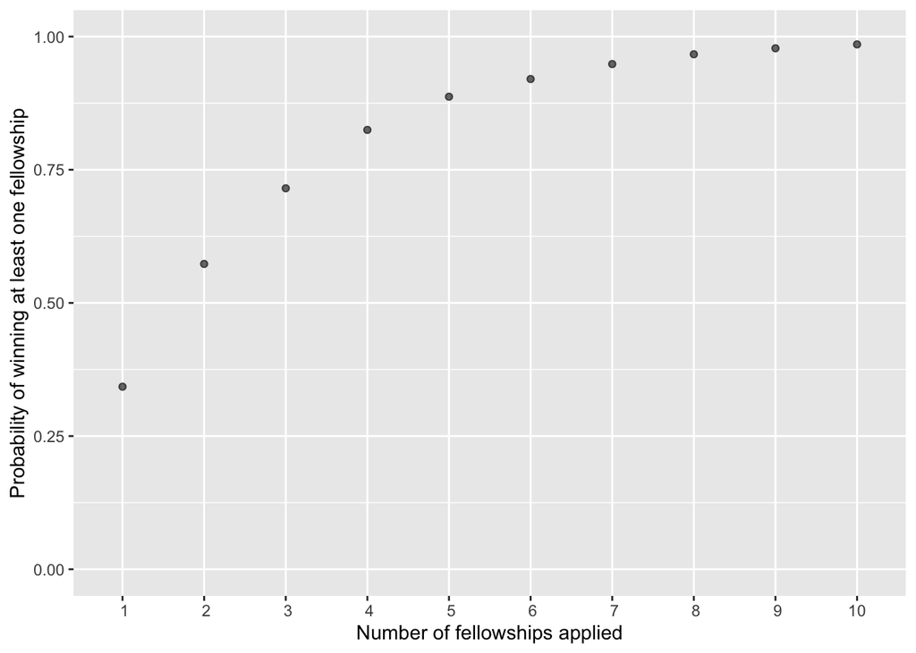

```r
# Create a data frame of probability of winning by positions applied to (All we do is win win win)
dfplot <- data.frame(x,y)
names(dfplot) <- c('APPS','PROB_WIN')

#str(dfplot)
#pdf('./figures/apps-by-prob.pdf', width = 6, height = 6)
ggplot(dfplot, aes(y= PROB_WIN, x = APPS)) +
        geom_point(alpha = 0.6) +
        ylab("Probability of winning at least one fellowship") +
        ylim(0,1.0) +
        scale_x_discrete(name ="Number of fellowships applied",
                         limits=1:10)
```

```r
#dev.off()
```

### Analysis Inspired by: [The Win](https://www.youtube.com/watch?v=GGXzlRoNtHU)